# Lab 09: Modeling Data 2 - No Walkthrough Code, For Submission

Johanna Ravenhurst

2022-11-30

I didn’t work with other students

```r
#Setup code
require(here)
```

# **Questions 1-2 Chi-square tests 1**

Q1 - *State the null hypothesis of the Chi-square test* Null hypothesis: On average, Brown Creepers are present with the same frequency in the edge and interior habitats.

```r
birds   = read.csv(here("data", "bird.sta.csv"))
hab     = read.csv(here("data", "hab.sta.csv"))
birdhab = merge(
  birds,
  hab, by=c("basin", "sub", "sta"))

# Create a contingency table for edge/interior and brown creeper presence/absence
table(
  birdhab$s.edge,
  birdhab$BRCR > 0)
```

```
##
##     FALSE TRUE
##   E   144   29
##   I   559  314
```

```r
# set the presence to be in the first column
br_creeper_table = table(
  birdhab$s.edge,
  birdhab$BRCR > 0)[, 2:1]

br_creeper_table
```

```
##
##     TRUE FALSE
##   E   29   144
##   I  314   559
```

```r
#Are brown creepers present more or less frequently than expected in forest interiors versus forest edges and is the difference significant?

rownames(br_creeper_table) = c("Edge", "Interior")
colnames(br_creeper_table) = c("Present", "Absent")
br_creeper_table
```

```
##
##            Present Absent
##   Edge          29    144
##   Interior     314    559
```

```r
chisq_creeper = chisq.test(br_creeper_table)
chisq_creeper
```

```
##
##  Pearson's Chi-squared test with Yates' continuity correction
##
## data:  br_creeper_table
## X-squared = 23.3, df = 1, p-value = 1.386e-06
```

```r
#Expected values
round(chisq_creeper$expected, 1)
```

```
##
##            Present Absent
##   Edge        56.7  116.3
##   Interior   286.3  586.7
```

```r
#Observed values
chisq_creeper$observed
```

```
##
##            Present Absent
##   Edge          29    144
##   Interior     314    559
```

```r
#Compare the residuals, or the difference between the observed and expected values
round(
  chisq_creeper$observed - chisq_creeper$expected,
  digits = 1)
```

```
##
##            Present Absent
##   Edge       -27.7   27.7
##   Interior    27.7  -27.7
```

Q2 - *Consider the results of your test and explain whether you think that Brown Creepers show a significant habitat preference.* The Chi-square test resulted in a p-value less than 0.001, indicating that we have significant evidence to reject the null hypothesis that there is no difference in Brown Creeper presence/absence when comparing edge and interior habitats. The Chi-Square test indicates that there is evidence of a habitat preference, but does not give us information about which habitat is preferred. In order to investigate which habitat was preferred by the Brown Creepers, I compared the expected and observed frequencies from the Chi square results. The third table in the output is the residuals, or the difference in frequency between expected and observed. This shows that the Brown Creepers showed a preference for the interior habitats, with a negative residual for edge forest presence and a positive residual for interior forest presence, showing 27.7 more Brown Creepers present in the interior habitats than expected.

# **Questions 3-5 Building Models for ANOVA**

```r
require(palmerpenguins)
#head(penguins)

#Q3 - Show the R-code you can use to create a model fit (call it fit_species) of penguin body mass as predicted by penguin species.
fit_species =
  lm(
    formula = body_mass_g ~ species,
    data = penguins)


#Q4 - Show the R-code you can use to create a model fit (call it fit_sex) of penguin body mass as predicted by sex.
fit_sex=
  lm(
    formula = body_mass_g ~ sex,
    data = penguins)



#Q5 - Show the R-code you can use to create a model fit (call it fit_both) of penguin body mass as predicted by species and sex. This should be an interactive model, i.e.it should include a sex and species interaction.
fit_both=
  lm(
    formula = body_mass_g ~ species * sex,
    data = penguins)
```

# **Questions 6-9 Homogeneity Assumption: Graphical**

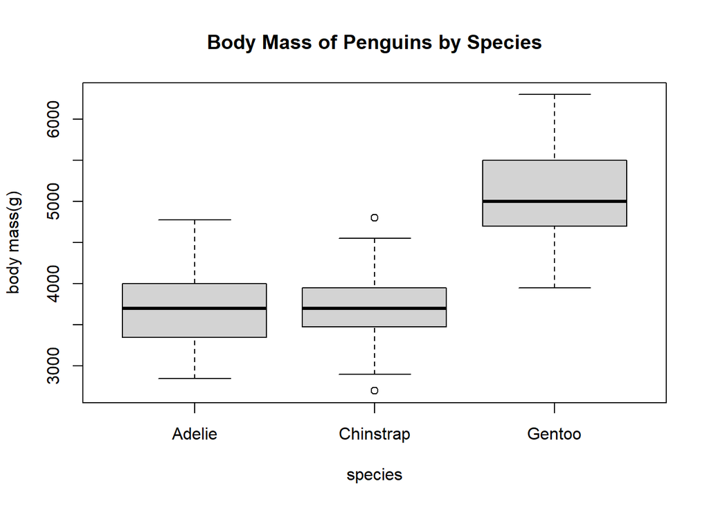

```r
#Q6 - Include a conditional boxplot corresponding to the grouping structure in your fit_species model.
 boxplot(
    body_mass_g ~ species, data = penguins,
    main = "Body Mass of Penguins by Species",
    ylab = "body mass(g)",
    xlab = "species")
```

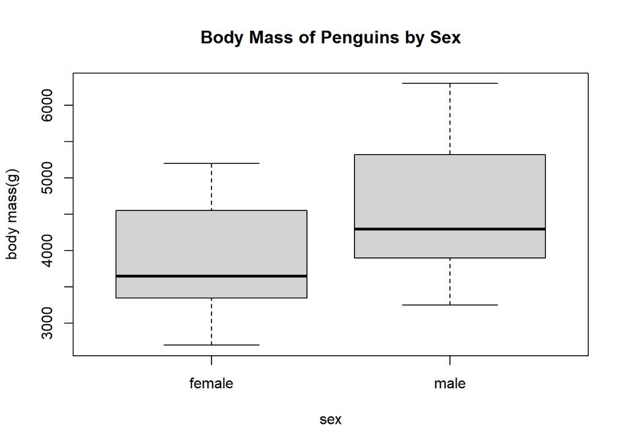

```r
#Q7 - Include a conditional boxplot corresponding to the grouping structure in your fit_sex model.
 boxplot(
    body_mass_g ~ sex, data = penguins,
    main = "Body Mass of Penguins by Sex",
    ylab = "body mass(g)",
    xlab = "sex")
```

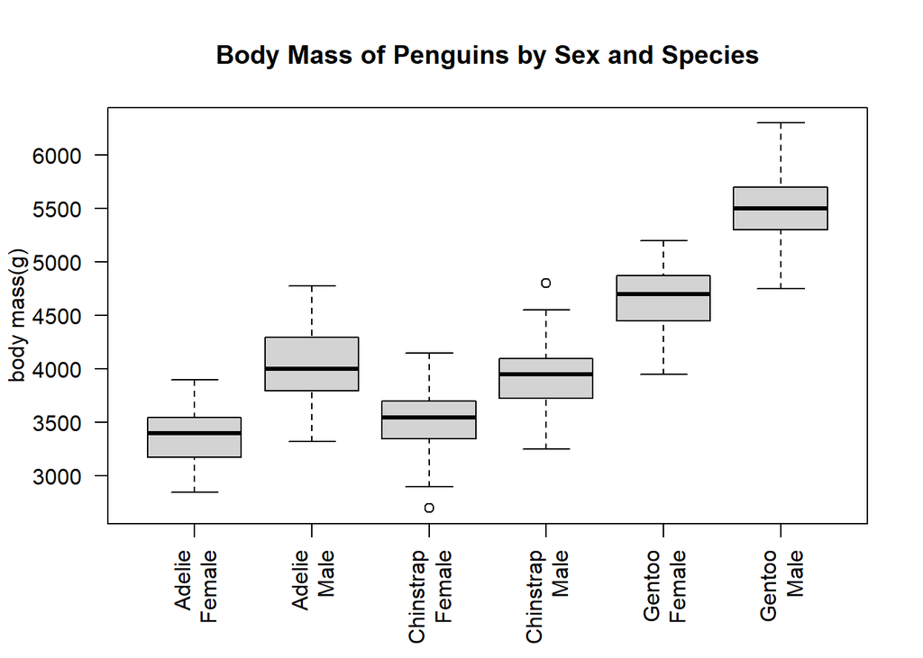

```r
#Q8 - Include a conditional boxplot corresponding to the grouping structure in your fit_both model. Your group labels must all correspond to the correct box, be visible, and sensible.

 boxplot(
    body_mass_g ~ sex:species, data = penguins,
    main = "Body Mass of Penguins by Sex and Species",
    ylab = "body mass(g)",
    xlab = NULL,
    names = c("Adelie\nFemale","Adelie\nMale", "Chinstrap\nFemale", "Chinstrap\nMale", "Gentoo\nFemale", "Gentoo\nMale"),
    las=2)
```

Q9 - *Based on the shapes of the boxes, which of the models (if any) do you think may have problems fulfilling the homogeneity assumption?* The fit_species model might not fit the homogeneity assumption because it looks like the Adelie and Gentoo boxes are wider than the Chinstrap box, indicating that those two species might have more variance. The fit_sex model looks like it should fulfill the homogeneity assumption, since the boxes look relatively similar in terms of width. The fit_both model might have some issues with unequal variance between the groups, since some of the boxes look a bit wider than the rest (Male Adelie is an example).

# **Questions 10-12 Homogeneity Assumption: Bartlett Test 1**

Q10 - *State the null hypothesis of the Bartlett test.* Null hypothesis = The variance in each group is equal to the variance in the other groups.

```r
bartlett.test(body_mass_g ~ species, data = penguins)
```

```
##
##  Bartlett test of homogeneity of variances
##
## data:  body_mass_g by species
## Bartlett's K-squared = 5.9895, df = 2, p-value = 0.05005
```

Q11 - *What was the p-value from the Bartlett test of homogeneity for observations grouped by species? You can round your answer to 4 decimal digits.* P-value = 0.0501

```r
bartlett.test(body_mass_g ~ sex, data = penguins)
```

```
##
##  Bartlett test of homogeneity of variances
##
## data:  body_mass_g by sex
## Bartlett's K-squared = 4.6017, df = 1, p-value = 0.03194
```

Q12 - *What was the p-value from the Bartlett test of homogeneity for observations grouped by sex? You can round your answer to 4 decimal digits.* p-value = 0.0319

# **Questions 13-14 Homogeneity Assumption: Bartlett Test 2**

```r
dat_groups = aggregate(
  body_mass_g ~ sex:species,
  data = penguins,
  FUN = c)
str(dat_groups)
```

```
## 'data.frame':    6 obs. of  3 variables:
##  $ sex        : Factor w/ 2 levels "female","male": 1 2 1 2 1 2
##  $ species    : Factor w/ 3 levels "Adelie","Chinstrap",..: 1 1 2 2 3 3
##  $ body_mass_g:List of 6
##   ..$ : int  3800 3250 3450 3625 3200 3700 3450 3325 3400 3800 ...
##   ..$ : int  3750 3650 4675 3800 4400 4500 4200 3600 3950 3800 ...
##   ..$ : int  3500 3525 3950 3250 4150 3800 3700 3575 3700 3450 ...
##   ..$ : int  3900 3650 3725 3750 3700 3775 4050 4050 3300 4400 ...
##   ..$ : int  4500 4450 4550 4800 4400 4650 4650 4200 4150 4800 ...
##   ..$ : int  5700 5700 5400 5200 5150 5550 5850 5850 6300 5350 ...
```

```r
bartlett.test(dat_groups$body_mass_g, data = penguins)
```

```
##
##  Bartlett test of homogeneity of variances
##
## data:  dat_groups$body_mass_g
## Bartlett's K-squared = 7.6908, df = 5, p-value = 0.1741
```

Q13 - *What was the p-value from the Bartlett test of homogeneity for observations grouped by both factors? You can round your answer to 4 decimal digits.* p-value = 0.1741

Q14 - *Based on the results of the Bartlett tests, do you anticipate any issues with heterogeneity in any of the models? Make sure you justify your response with the results of your tests.* The Bartlett test result for the fit_species model was a p-value of 0.0501, which is a borderline result but we could decide not to reject the null hypothesis of homogeneity of variance based on the p-value of 0.05. The Bartlett test result for the fit_sex model was a p-value of 0.0319, which indicates that we have significant evidence to reject the null hypothesis of homogeneity between male and female penguins. This is an issue because these data don’t satisfy the assumption of constant variance. The Bartlett test result for the fit_both model was a p-value of 0.1741, which indicates that we should not reject the null hypothesis of homogeneity.

# **Question 15 - Florida Trees**

```r
dat_fl = read.csv(here("data", "trees_FL.csv"))
#head(dat_fl)
#str(dat_fl)
#summary(dat_fl)
```

Q15 - *Perform a graphical exploration of the dataset. Create the following plots and include them in your report. You may create separate figures, or combine them into one multi-panel figure.*

```r
#A barplot of counts of trees in each probability of failure class (column ProbabilityofFailure.
tree_count_probfail = table(dat_fl$ProbabilityofFailure)
tree_count_probfail
```

```
##
##    1    2    3    4
## 1407  889  627  116
```

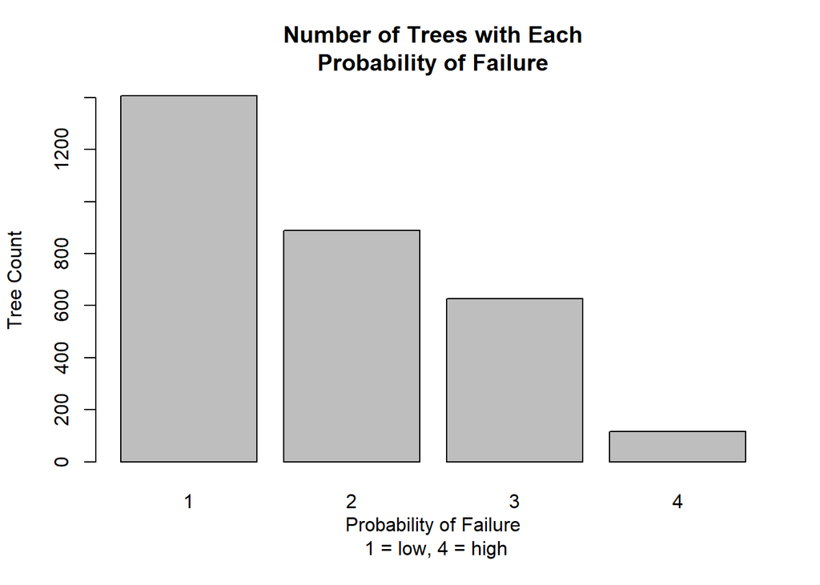

```r
barplot(
  tree_count_probfail,
  main = "Number of Trees with Each\nProbability of Failure",
  xlab = "Probability of Failure\n 1 = low, 4 = high",
  ylab = "Tree Count")
```

```r
#A barplot of the counts of trees in each of the failure classes (column Failure_Standardized)
tree_count_fail = table(dat_fl$Failure_Standardized)[c(2, 1, 3)]
tree_count_fail
```

```
##
##   none branch  whole
##   2389    438    219
```

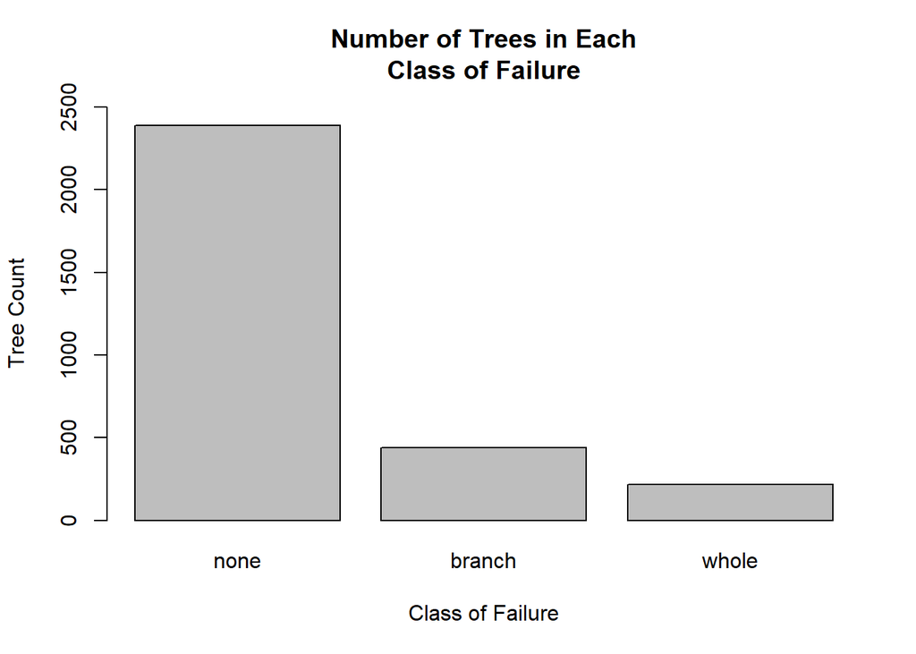

```r
barplot(
  tree_count_fail,
  main = "Number of Trees in Each\nClass of Failure",
  xlab = "Class of Failure",
  ylab = "Tree Count",
  ylim = c(0,2500))
```

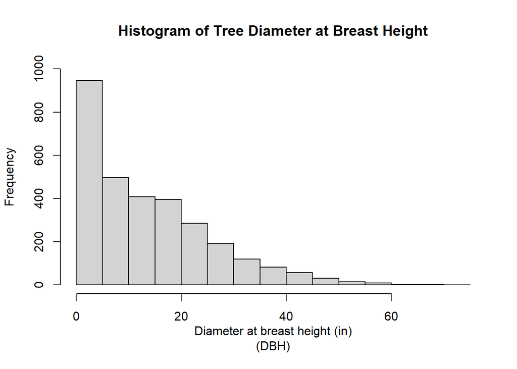

```r
#A histogram of DBH
hist(
  dat_fl$DBH_in,
  main = "Histogram of Tree Diameter at Breast Height",
  xlab = "Diameter at breast height (in)\n(DBH)",
  ylim = c(0,1000))
```

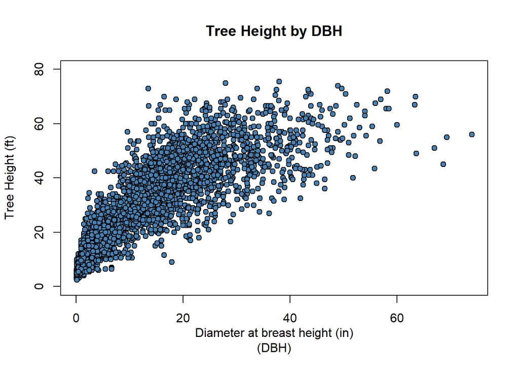

```r
#Scatterplot of DBH (x-axis) and tree height (y axis)
plot(
  HeighttoTop_ft ~ DBH_in,
  data = dat_fl,
  main = "Tree Height by DBH",
  xlab = "Diameter at breast height (in)\n(DBH)",
  ylab = "Tree Height (ft)",
  pch = 21, col = 1, bg = "steelblue",
  ylim = c(0,80)
)
```

# **Question 16-17 - Florida Trees: Compare Distributions**

Q16 - *State the null hypothesis for the Kolmogorov-Smirnov test. Your answer should be in terms of the DBH of the two groups of trees.* Null hypothesis - The DBH sample distributions are the same for trees in the whole failure and intact tree classes.

```r
#HINT: It may be convenient to create subsets of the FL tree data, one each for the none and whole failure types.
dat_fl2 = droplevels(
  subset(
    dat_fl,
    Failure_Standardized %in% c('whole','none')
  ))

# verify that failure class is factorized
dat_fl2$Failure_Standardized = factor(dat_fl2$Failure_Standardized)
summary(dat_fl2$Failure_Standardized)
```

```
##  none whole
##  2389   219
```

```r
#Note: I realized after doing all of this that I probably could have just used the original dataset since I figured out how to select certain levels of a variable within the code by looking at some walkthrough examples

ks.test(dat_fl2$DBH_in[dat_fl2$Failure_Standardized == "none"], dat_fl2$DBH_in[dat_fl2$Failure_Standardized == "whole"])
```

```
##
##  Asymptotic two-sample Kolmogorov-Smirnov test
##
## data:  dat_fl2$DBH_in[dat_fl2$Failure_Standardized == "none"] and dat_fl2$DBH_in[dat_fl2$Failure_Standardized == "whole"]
## D = 0.10643, p-value = 0.02125
## alternative hypothesis: two-sided
```

Q17 - *What was the p-value of the test? Based on the evidence, do you think the distribution of DBH is the same for the two groups?*

P-value = 0.0213 This p-value is less than 0.05, so we have significant evidence to reject the null hypothesis that the distribution of DBH is the same for the whole failure trees and the intact trees. I think the distribution of DBH for the two groups is different based on the results of this test.

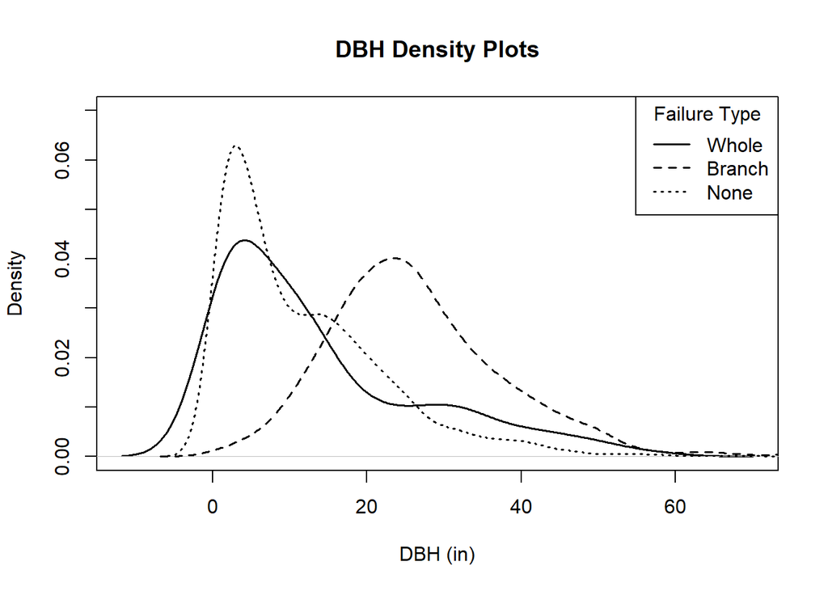

```r
plot(
  density(dat_fl2$DBH_in[dat_fl2$Failure_Standardized == "whole"]),
  main = "DBH Density Plots",
  xlab = "DBH (in)",
  ylab = "Density",
  col= "black",lwd=1.5, lty = 1,
  ylim = c(0, 0.07))

lines(
  density(dat_fl$DBH_in[dat_fl$Failure_Standardized == "branch"]),
  col = "black", lwd=1.5, lty = 2)

lines(
  density(dat_fl2$DBH_in[dat_fl2$Failure_Standardized == "none"]),
  col = "black", lwd=1.5, lty = 3)

legend(
  x="topright",
  bty="o",
  title = "Failure Type",
  legend=c('Whole', 'Branch', 'None'),
  lty=c(1, 2, 3), lwd=1.5)
```

# **Questions 18-20 - Florida Trees: Correlations**

Q18 - *Qualitatively describe the shape of the relationship between DBH and height. Is it linear? Curved? Monotonic?*

The shape is curved and monotonically increasing. It also looks like the variance in tree height from the mean increases with increasing values of DBH.

Q19 - *Given your answer to the previous question, which type of correlation coefficient is most appropriate?* Spearman and Pearson correlations can both be used for monotonic functions. I think Spearman is more appropriate for these data because it is a non-parametric measure of association that is more forgiving of violations of our standard assumptions.

```r
cor.test(
  dat_fl$DBH_in,
  dat_fl$HeighttoTop_ft,
  use='complete.obs',
  method='spearman')
```

```
##
##  Spearman's rank correlation rho
##
## data:  dat_fl$DBH_in and dat_fl$HeighttoTop_ft
## S = 541454081, p-value < 2.2e-16
## alternative hypothesis: true rho is not equal to 0
## sample estimates:
##       rho
## 0.8850462
```

Q20 - *What is the p-value? Do you conclude that the two variables are significantly correlated?* p-value < 2.2e-16, or less than 0.0001 Yes, I conclude that we have significant evidence to reject the null hypothesis of no correlation between DPH and tree height. The rho value is 0.885, which indicates strong positive correlation because it is close to 1.

# **Questions 21-25 - Florida Trees: Risk Rating**

```r
dat_fl$fail = factor(dat_fl$Failure_Standardized != "none")

levels(dat_fl$fail) = c("No Fail", "Fail")

fl_table_2 = table(
  dat_fl$ProbabilityofFailure,
  dat_fl$fail)
fl_table_2
```

```
##
##     No Fail Fail
##   1    1239  168
##   2     670  219
##   3     421  206
##   4      53   63
```

```r
#Chi-square test and residuals
chisq_fail = chisq.test(fl_table_2)
chisq_fail
```

```
##
##  Pearson's Chi-squared test
##
## data:  fl_table_2
## X-squared = 202.65, df = 3, p-value < 2.2e-16
```

```r
#Expected values
round(chisq_fail$expected, 1)
```

```
##
##     No Fail  Fail
##   1  1103.3 303.7
##   2   697.1 191.9
##   3   491.7 135.3
##   4    91.0  25.0
```

```r
#Observed values
chisq_fail$observed
```

```
##
##     No Fail Fail
##   1    1239  168
##   2     670  219
##   3     421  206
##   4      53   63
```

```r
#Compare the residuals, or the difference between the observed and expected values
round(
  chisq_fail$observed - chisq_fail$expected,
  digits = 1)
```

```
##
##     No Fail   Fail
##   1   135.7 -135.7
##   2   -27.1   27.1
##   3   -70.7   70.7
##   4   -38.0   38.0
```

Q21 - *What was the value of the test statistic (X-squared)? What was the corresponding p-value?* X-squared = 202.65 p-value < 2.2e-16, or less than 0.0001

Q22 - *What is the value of the chi-square residual (rounded to the nearest whole number) for the count of failures in probability category 1?* -136

Q23 - *Were there more, or fewer, tree failures than expected by chance in failure probability category #1?* Fewer

Q24 - *Were there more, or fewer, tree failures than expected by chance in failure probability category #4?* More

Q25 - *Given your answers to the previous two questions, do you conclude that the probability of failure rating system is effective?* Yes, it seems like the failure rating system is effective at predicting which trees are more likely to fail.